# Univariate Plots Section

# Multivariate Analysis

### Talk about some of the relationships you observed in this part of the investigation. Were there features that strengthened each other in terms of looking at your feature(s) of interest?

density，alcohol和residual.sugar三个变量的多元线性回归效果较好，但是变量的系数比较小。

### Were there any interesting or surprising interactions between features?

该数据集中数据的离散程度比较高，相关性检验的效果并不好，散点图的统一特征是在较小的区域比较集中。

### OPTIONAL: Did you create any models with your dataset? Discuss the strengths and limitations of your model.

多元线性回归，找出三变量之间的回归方程，实际上变量的系数比较小，做回归的效果显示很好，但是实际上做进一步分析时，发现效果好是因为数据在较小的范围内重叠的区域较多，这种情况用多元回归，即使R-squared达到0.9，但是模型是没有实际意义的。

# Final Plots and Summary

### Plot One

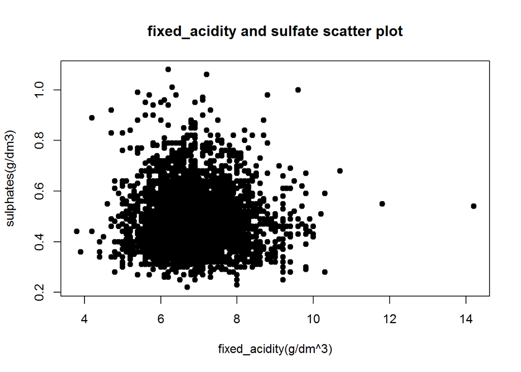

### Description One

fixed.acidity和sulphates变量的数据集主要在fixed.acidity的6-8之间。

### Plot Two

```
## [1] "C"
```

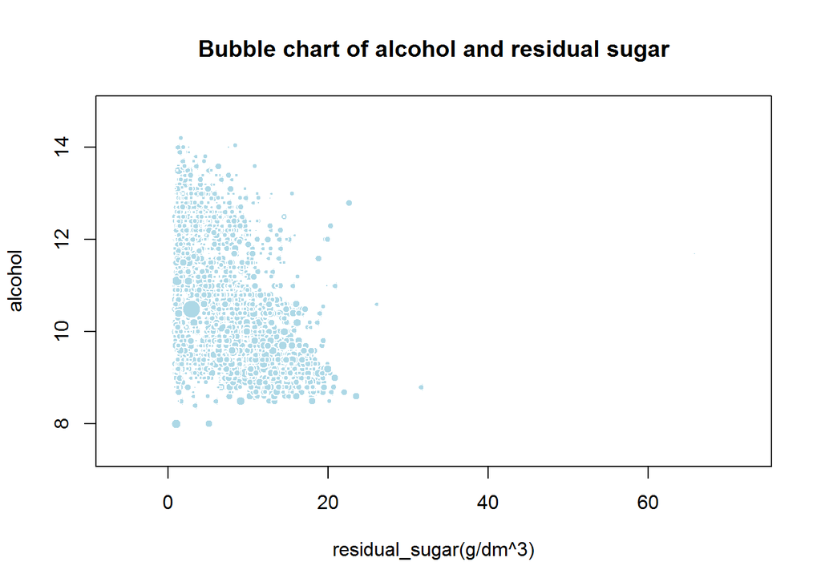

### Description Two

气泡图显示“free.sulfur.dioxide”，“residual.sugar”和“alcohol”三个变量的关系，其中变量“free.sulfur.dioxide”做了处理。里面可以看到一个比较大的图，该部分的数据量较为集中。

### Plot Three

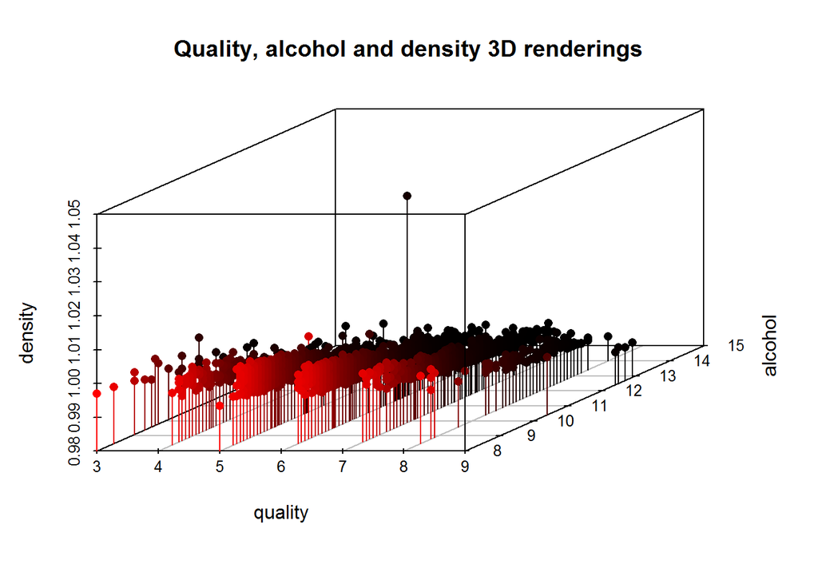

### Description Three

把密度，品质和酒精三个变量之间的散点图，数据较为集中在品质的5、6和7中，密度数据较为密集，没有拉开。

# Reflection

从拿到数据集，在做初步探索的时候，是想创建一个模型用以解释影响quality的因素，那些变量是强影响，那些相对较弱些变量。通过探索数据集，发现问题和线索，并建立了简单的回归模型和多元回归模型，在这过程中，发现变量之间的相关性非常低，这就是实际工作中数据，跟课程中学习的数据的相关性较高的数据，模型拟合好存在很多的差异。后面又通过其他方法，把一直线性回归的R-squared比较高来衡量模型的好坏，又给推翻了。可能实际中quality的好坏需要各种成分的不同配比，数据中不同变量数据大小的差异又非常小，这种细微的差异，分析出来的结果反而不是那么的明显。

在项目过程中，在单变量分析过程中就发现，大部分变量分布有很多相似性，没有很突出的特征，模型实际用处不大。在实际的工作中进行数据分析，可以需要做很多数据处理的部分，尽管会花费很多时间，但是最后有价值的部分确却很少。所有说能够理解这样一句话，做数据分析会花80%时间在数据的处理上，这也不是没有道理的。所以，做好充足的心里准备，你将花费大量的时间做些基础的数据处理工作。

同时，要能够理解模型的适用条件，模型中存在的缺点和优点，以及最适用哪种情形下图形的分析，还需要花很多时间理解和巩固。